# Migrating from qgraph to splot

This guide introduces `splot()`, the main plotting function in `cograph`, and helps `qgraph` users transition to it.

# About splot

`splot()` is the primary plotting engine of `cograph`. It renders network graphs using base R graphics and is designed to work across a wide range of use cases: transition networks from learning analytics, correlation networks from psychology, social networks, and any weighted or unweighted graph structure. It accepts adjacency matrices, edge lists, igraph objects, tna objects, and qgraph objects directly, so it fits into existing workflows without requiring format conversion.

The function is built to be useful at every stage of analysis. A single call like `splot(mat)` produces a clean, readable plot with sensible defaults. But when you need more, the same function supports confidence interval underlays on edges, significance stars derived from p-values, templated edge labels that combine estimates with CI ranges and stars (e.g., `0.25*** [0.12, 0.38]`), pie and donut charts on nodes, and publication-quality export at 600 DPI. The goal is that you should not need to switch tools as your analysis moves from exploration to a final manuscript figure.

## Naming conventions

One of the deliberate choices in `splot()` is a consistent, predictable parameter naming system. Every parameter is prefixed by the element it controls – `node_`, `edge_`, `label_`, `donut_`, `pie_`, `edge_label_`, `edge_ci_` – followed by the property: `size`, `color`, `fill`, `width`, `alpha`, and so on. So `node_fill` is the node fill color, `edge_label_size` is the edge label font size, `donut_border_color` is the donut border color, and `edge_ci_alpha` is the confidence interval underlay transparency. The naming is designed so that once you learn the pattern, you can guess parameter names without checking the documentation. This contrasts with conventions like `vsize`, `posCol`, `border.width`, `label.cex`, and `pieColor`, where every parameter follows a different convention and needs to be memorized individually.

## Statistical annotations

Network plots in research often need to communicate uncertainty and significance alongside the graph structure itself. `splot()` treats this as a first-class concern rather than an afterthought. Edges can carry confidence interval underlays (`edge_ci`) – semi-transparent bands behind each edge whose width reflects the uncertainty of the estimate. Edge labels can be built from templates (`edge_label_template`) using placeholders like `{est}`, `{stars}`, `{low}`, `{up}`, `{range}`, and `{p}`, which are filled in from vectors of CI bounds and p-values that you supply. Significance stars are computed automatically from p-values when `edge_label_stars = TRUE`. These features mean that a single `splot()` call can produce a network where every edge shows its weight, its significance level, and its confidence interval – information that would otherwise require post-processing or manual annotation.

## Inputs and compatibility

`splot()` accepts square adjacency matrices, data frames with edge lists (from, to, weight columns), igraph objects, cograph network objects, tna objects, and qgraph objects. For users migrating from `qgraph`, the `from_qgraph()` function converts a fitted qgraph object into splot parameters, and `tplot()` provides a wrapper that accepts qgraph-style parameter names (`vsize`, `edge.labels`, `posCol`) for a smoother transition.

```r
library(cograph)
library(qgraph)
```

# Create a transition matrix

```r
states <- c("Read", "Watch", "Try", "Ask", "Discuss",
            "Review", "Search", "Reflect", "Submit")

mat <- matrix(c(
  0.00, 0.25, 0.15, 0.00, 0.10, 0.00, 0.08, 0.00, 0.00,
  0.10, 0.00, 0.30, 0.00, 0.00, 0.12, 0.00, 0.00, 0.00,
  0.00, 0.10, 0.00, 0.20, 0.00, 0.00, 0.00, 0.15, 0.25,
  0.05, 0.00, 0.10, 0.00, 0.30, 0.00, 0.00, 0.00, 0.00,
  0.00, 0.00, 0.00, 0.15, 0.00, 0.20, 0.00, 0.18, 0.00,
  0.12, 0.08, 0.00, 0.00, 0.00, 0.00, 0.10, 0.00, 0.20,
  0.00, 0.00, 0.15, 0.00, 0.00, 0.10, 0.00, 0.00, 0.12,
  0.00, 0.00, 0.10, 0.00, 0.12, 0.00, 0.00, 0.00, 0.28,
  0.00, 0.00, 0.00, 0.00, 0.00, 0.10, 0.00, 0.05, 0.00
), nrow = 9, byrow = TRUE, dimnames = list(states, states))
```

# Parameter mapping

## Node parameters

| qgraph | splot | Notes |
| --- | --- | --- |
| `vsize` | `node_size` | Same scale |
| `shape` | `node_shape` | “circle”, “square”, “triangle”, etc. |
| `color` | `node_fill` | Node fill color |
| `border.color` | `node_border_color` |  |
| `border.width` | `node_border_width` |  |
| `labels` | `labels` | TRUE, FALSE, or character vector |
| `label.cex` | `label_size` |  |
| `label.color` | `label_color` |  |

## Edge parameters

| qgraph | splot | Notes |
| --- | --- | --- |
| `edge.color` | `edge_color` |  |
| `edge.width` | `edge_width` |  |
| `edge.labels` | `edge_labels` | TRUE shows weights |
| `edge.label.cex` | `edge_label_size` |  |
| `lty` | `edge_style` | 1=solid, 2=dashed, 3=dotted |
| `curve` | `curvature` | Curve amount |
| `asize` | `arrow_size` | Arrow head size |
| `posCol` | `edge_positive_color` | Positive weight color |
| `negCol` | `edge_negative_color` | Negative weight color |
| `minimum` | `threshold` | Min weight to display |
| `directed` | `directed` | TRUE/FALSE/NULL (auto) |

## Layout and display

| qgraph | splot | Notes |
| --- | --- | --- |
| `layout` | `layout` | “circle”, “spring”, “fr”, “kk”, etc. |
| `groups` | `groups` | For coloring/legend |
| `legend` | `legend` | TRUE/FALSE |
| `title` | `title` | Plot title |
| `filetype` | `filetype` | “png”, “pdf”, “svg”, etc. |

## Pie and donut

| qgraph | splot | Notes |
| --- | --- | --- |
| `pie` | `donut_fill` | Single value 0-1 per node |
| `pie` (list) | `pie_values` | Multiple segments per node |
| `pieColor` | `donut_color` | Fill color(s) |

# Example 1: Default plot

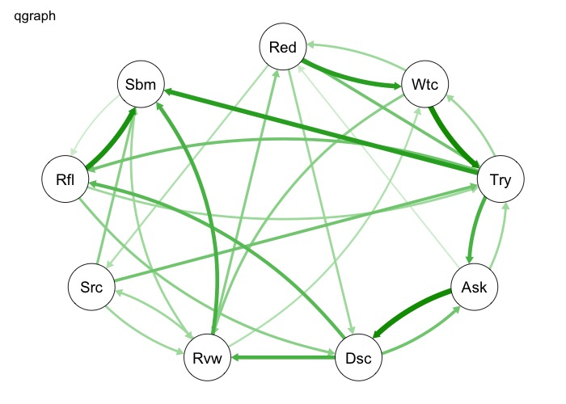

```r
qgraph(mat, layout = "circle", vsize = 9, title = "qgraph")
```

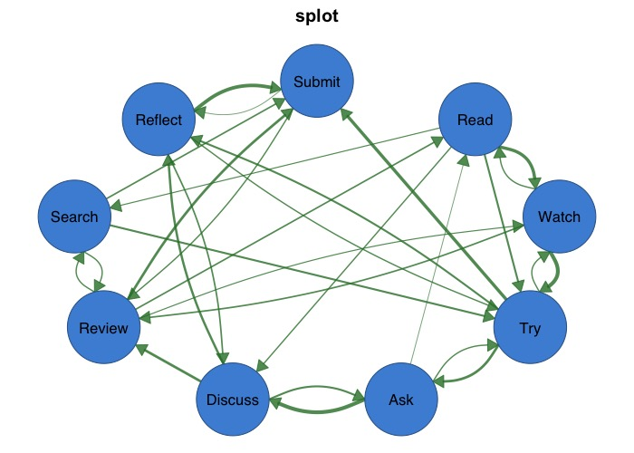

```r
splot(mat, node_size = 9, title = "splot")
```

# Example 2: Edge labels

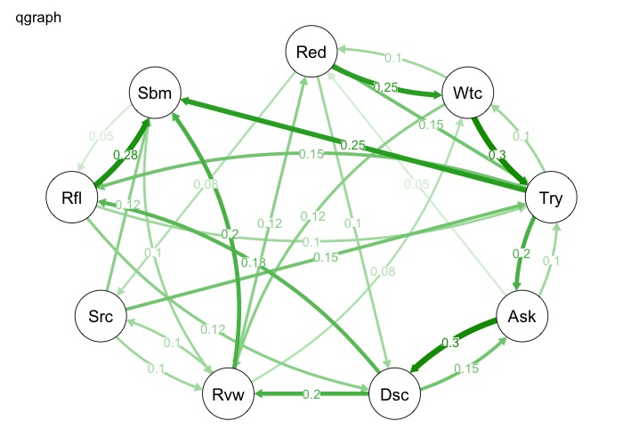

```r
qgraph(mat, layout = "circle", vsize = 9, edge.labels = TRUE, title = "qgraph")
```

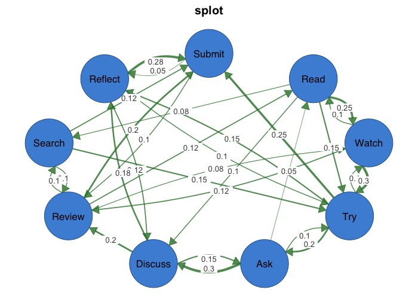

```r
splot(mat, node_size = 9, edge_labels = TRUE, title = "splot")
```

# Example 3: Custom edge colors

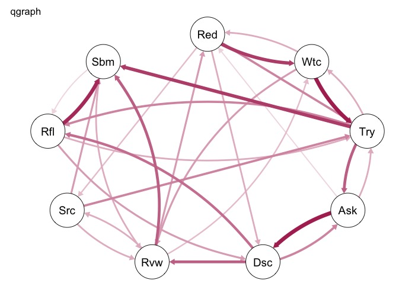

```r
qgraph(mat, layout = "circle", vsize = 9, posCol = "maroon", negCol = "red", title = "qgraph")
```

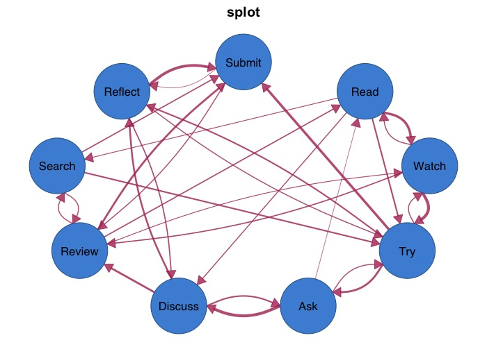

```r
splot(mat, node_size = 9, edge_positive_color = "maroon",
      edge_negative_color = "red", title = "splot")
```

# Example 4: Node shapes and colors

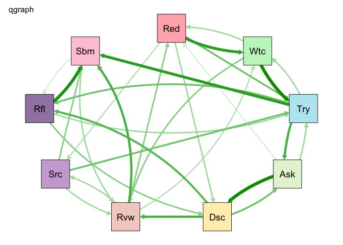

```r
cols <- palette_pastel(9)

qgraph(mat, layout = "circle", vsize = 9, shape = "square", color = cols, title = "qgraph")
```

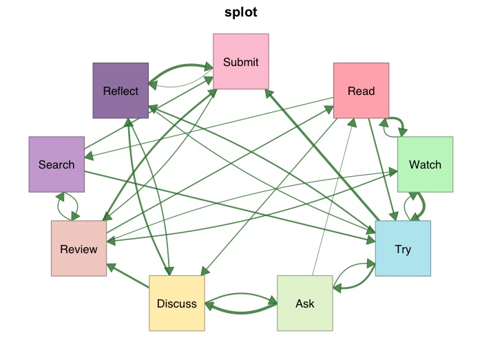

```r
splot(mat, node_size = 9, node_shape = "square", node_fill = cols, title = "splot")
```

# Example 5: Curved edges

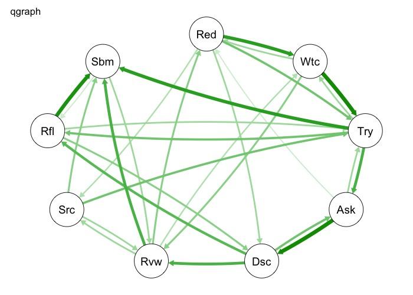

```r
qgraph(mat, layout = "circle", vsize = 9, curve = 0.3, curveAll = TRUE, title = "qgraph")
```

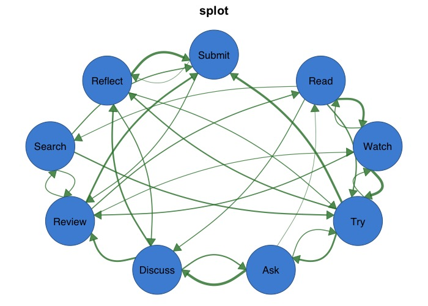

```r
splot(mat, node_size = 9, curvature = 0.3, curves = "force", title = "splot")
```

# Example 6: Donut nodes

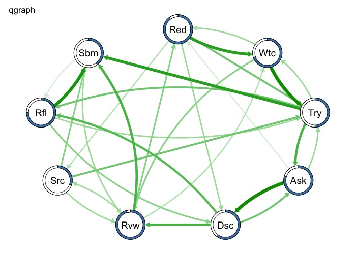

```r
fills <- c(0.9, 0.7, 0.5, 0.8, 0.6, 0.95, 0.3, 0.75, 0.4)

qgraph(mat, layout = "circle", vsize = 9, pie = fills, pieColor = "steelblue", title = "qgraph")
```

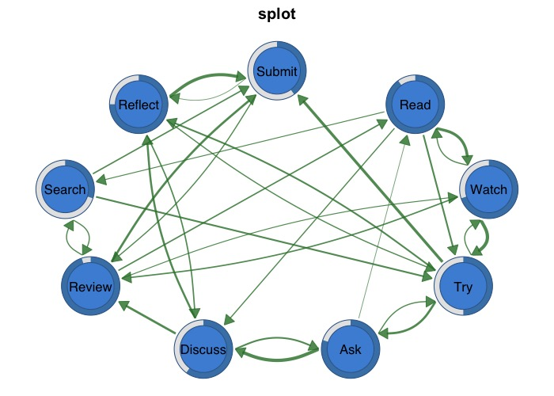

```r
splot(mat, node_size = 9, donut_fill = fills, donut_color = "steelblue", title = "splot")
```

# Example 7: Using qgraph’s layout in splot

`splot()` accepts a qgraph object’s layout matrix directly.

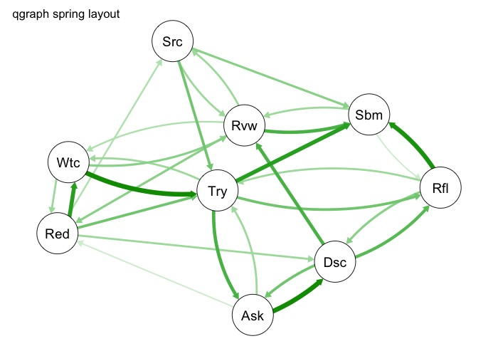

```r
q <- qgraph(mat, layout = "spring", vsize = 9, title = "qgraph spring layout")
```

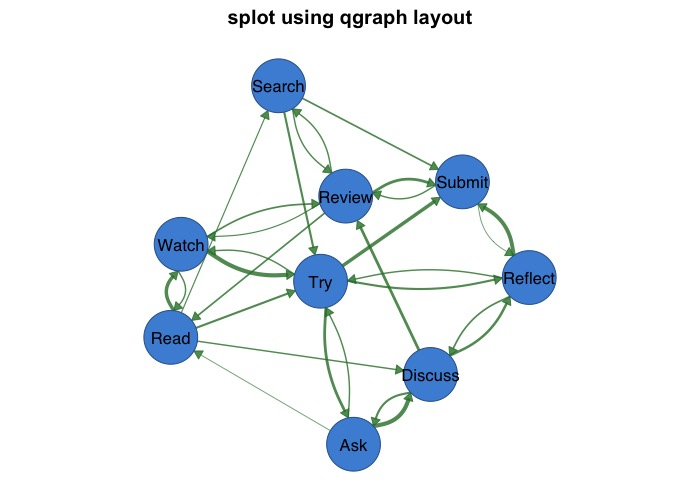

```r
splot(mat, layout = q$layout, node_size = 9, title = "splot using qgraph layout")
```

# Example 8: Converting existing qgraph objects

Use `from_qgraph()` to convert a qgraph object directly.

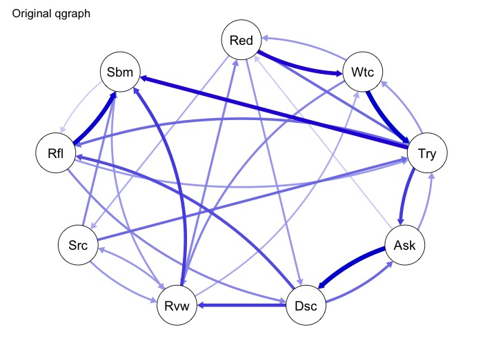

```r
q <- qgraph(mat, layout = "circle", vsize = 9, theme = "colorblind", title = "Original qgraph")
```

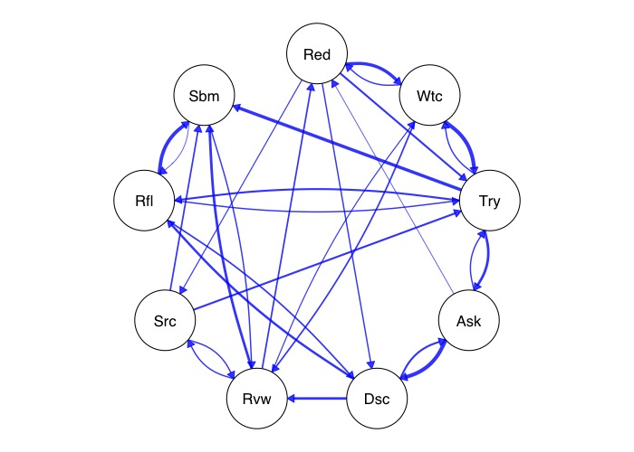

```r
from_qgraph(q)
```

# Example 9: Extracting and tweaking qgraph parameters

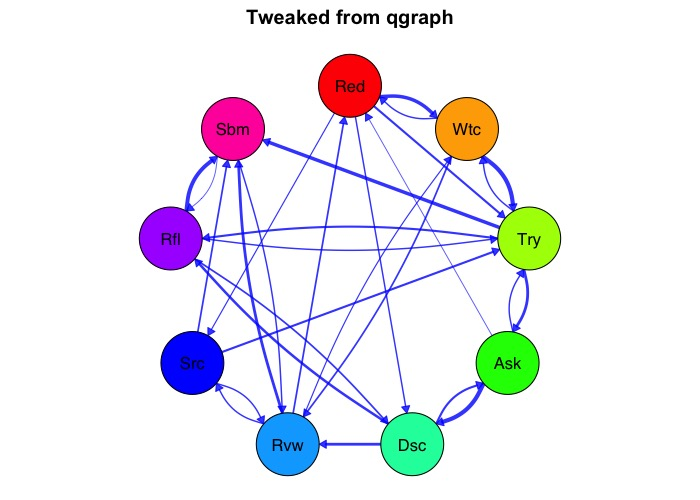

```r
params <- from_qgraph(q, plot = FALSE)
params$node_fill <- palette_rainbow(9)
params$title <- "Tweaked from qgraph"
do.call(splot, params)
```

# Example 10: tplot for qgraph-style parameter names

`tplot()` accepts qgraph-style parameter names like `vsize`, `edge.labels`, and `posCol`.

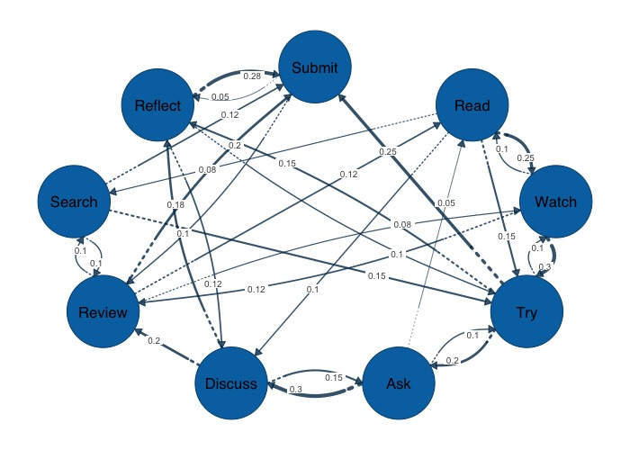

```r
tplot(mat, vsize = 9, edge.labels = TRUE)
```

# Features unique to splot

## CI underlays

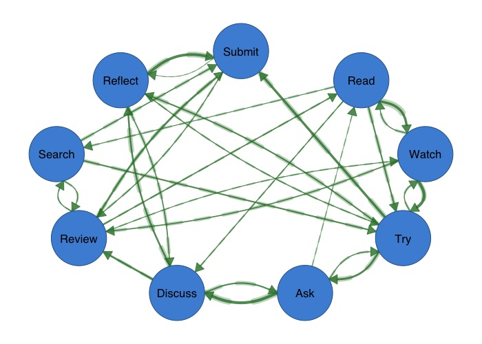

```r
net <- cograph(mat)
ne <- nrow(get_edges(net))

set.seed(42)
ci_widths <- runif(ne, 0.1, 0.4)

splot(mat, node_size = 9,
      edge_ci = ci_widths,
      edge_ci_scale = 5,
      edge_ci_alpha = 0.3)
```

## CI range labels

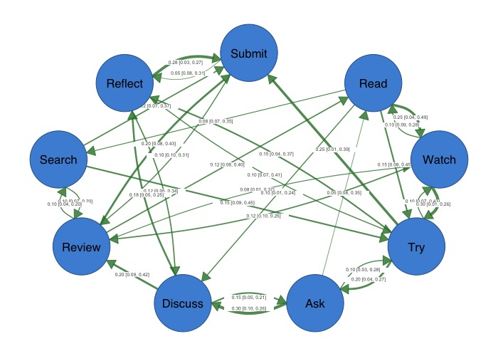

```r
ci_lower <- runif(ne, 0.01, 0.10)
ci_upper <- runif(ne, 0.20, 0.50)

splot(mat, node_size = 9,
      edge_label_template = "{est} [{low}, {up}]",
      edge_ci_lower = ci_lower,
      edge_ci_upper = ci_upper,
      edge_label_size = 0.4)
```

## Edge label templates with significance stars

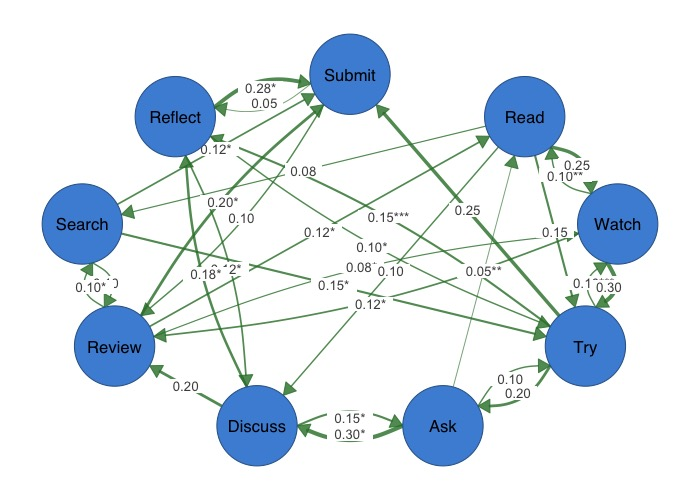

```r
p_values <- round(runif(ne, 0.0001, 0.08), 4)

splot(mat, node_size = 9,
      edge_label_template = "{est}{stars}",
      edge_label_p = p_values,
      edge_label_stars = TRUE)
```

## Pie chart nodes

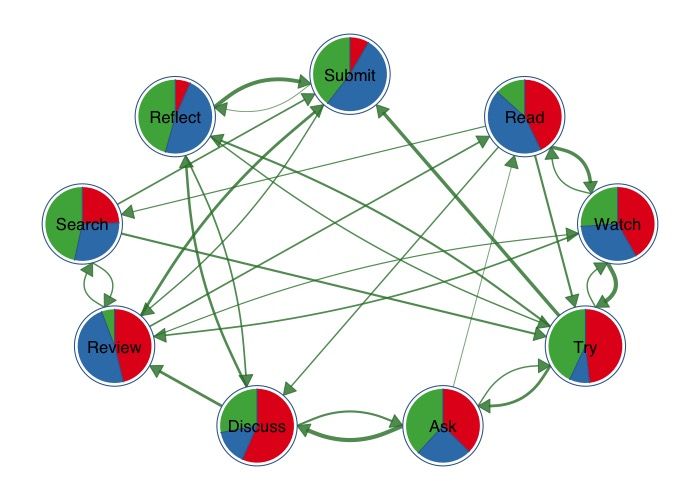

```r
set.seed(42)
pie_vals <- lapply(1:9, function(i) {
  v <- runif(3)
  v / sum(v)
})

splot(mat, node_size = 9,
      pie_values = pie_vals,
      pie_colors = rep(list(c("#E41A1C", "#377EB8", "#4DAF4A")), 9))
```

## Polygon donut shapes

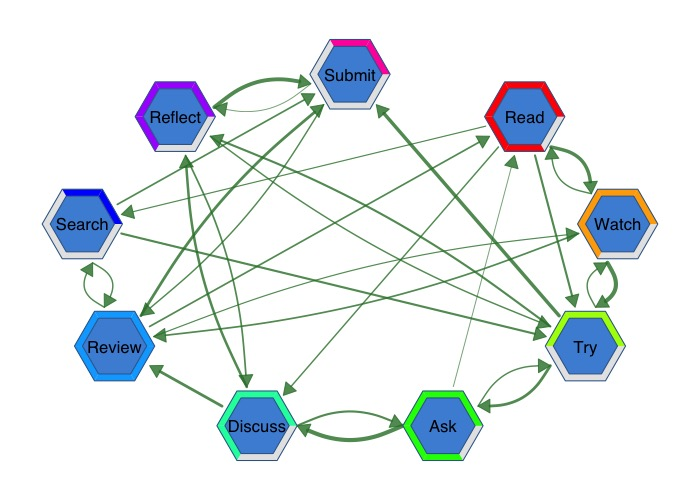

```r
splot(mat, node_size = 9,
      donut_fill = fills,
      donut_color = palette_rainbow(9),
      donut_shape = "hexagon")
```

## Double donuts

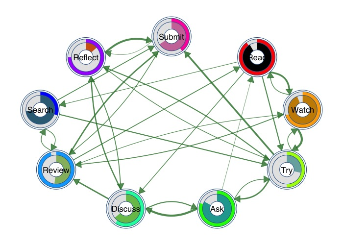

```r
splot(mat, node_size = 9,
      donut_fill = fills,
      donut_color = palette_rainbow(9),
      donut2_values = lapply(1:9, function(i) runif(1)),
      donut2_colors = lapply(palette_colorblind(9), function(x) x))
```